# TRGN510_Final_Project

Mengyuan Zhang

10/25/2020

# Check current working directory

```r
getwd()
```

```
## [1] "/Users/zmyyy/Desktop/510/final_project"
```

# Data Packaging

## Set working directory

```r
setwd("/Users/zmyyy/Desktop/510/final_project/raw_young")
```

## Load the packages that will be used in the following steps

```r
library(R.utils)
library(stringr)
library(dplyr)
library(Homo.sapiens)
library(gsubfn)
options(stringsAsFactors = FALSE)
```

## Load and integrate the data of young group

Unzip the original data folder of young group

```r
#you may need the following code to unzip the original data
#R.utils::gunzip("gdc_download_20201027_215715.193634.tar.gz")
```

Untar the original data folder

```r
#you may need the following code to untar the original data
#utils::untar("gdc_download_20201027_215715.193634.tar", exdir = ".")
```

Create a new folder named “row_young_data”

```r
setwd("/Users/zmyyy/Desktop/510/final_project")
dir.create('raw_young_data')
```

Find all of files contained in the original data folder, and copy all of the files into the new folder we created last step.

```r
for (dirname in dir('raw_young')){
  file <- list.files(paste0(getwd(),'/raw_young/',dirname), pattern = '*.counts')
  file.copy(paste0(getwd(),'/raw_young/',dirname,'/',file), 'raw_young_data')
}
```

```r
setwd("/Users/zmyyy/Desktop/510/final_project/raw_young_data")
```

Because the original names of files are so complicated, I am going to give these files new names for this project to easily indentify them. Create list1 that containd 20 file names.

```r
list1 <- list.files("/Users/zmyyy/Desktop/510/final_project/raw_young_data", pattern = '*.gz')
list1
```

```
##  [1] "08b7568c-c002-43ff-8f86-4be189aada9e.htseq.counts.gz"
##  [2] "15b87438-308c-491e-ac85-6fb75a470182.htseq.counts.gz"
##  [3] "19ad10e2-bcfe-4b8a-ba4e-1b59f352050e.htseq.counts.gz"
##  [4] "42016929-9d4d-4125-b2f2-4b472c3fd772.htseq.counts.gz"
##  [5] "47efad89-24a3-4864-8a60-9315167f304f.htseq.counts.gz"
##  [6] "4ea99594-481e-4d33-9969-da0a90797d23.htseq.counts.gz"
##  [7] "5347b69e-eb89-4c1f-829f-3787b6d7db62.htseq.counts.gz"
##  [8] "677291bf-6149-4c97-b958-dd2b0219bfe5.htseq.counts.gz"
##  [9] "793a4160-f480-4ca2-9afd-42ffec3dc717.htseq.counts.gz"
## [10] "7a241ae9-e218-4479-8096-d855cf3e8565.htseq.counts.gz"
## [11] "7b50493c-0691-4612-9721-d8cce38e847b.htseq.counts.gz"
## [12] "80b5f1bb-3134-438d-8918-b63c73a44e0f.htseq.counts.gz"
## [13] "9943770b-b3e2-42c9-a286-85b558de7da3.htseq.counts.gz"
## [14] "a7ee7e2c-0788-4505-82d0-3db8bb56ea6b.htseq.counts.gz"
## [15] "ab2983e3-716c-4374-81a2-2837cf76930e.htseq.counts.gz"
## [16] "b46583df-2e98-4507-a730-581cfe113900.htseq.counts.gz"
## [17] "bbe0252c-d51f-4e74-96b6-e4a0355ccda0.htseq.counts.gz"
## [18] "c15643a8-ed70-40ff-8379-b58cea01ad49.htseq.counts.gz"
## [19] "e99fba98-f95e-4fc9-aa7d-5f8164c06f2a.htseq.counts.gz"
## [20] "f959f0c8-c6be-4601-817a-ee24a17b4432.htseq.counts.gz"
```

Create list2 that containd the 20 new names

```r
list2 <- str_c(c("young"), c(1:20), sep = "_")
list2
```

```
##  [1] "young_1"  "young_2"  "young_3"  "young_4"  "young_5"  "young_6"
##  [7] "young_7"  "young_8"  "young_9"  "young_10" "young_11" "young_12"
## [13] "young_13" "young_14" "young_15" "young_16" "young_17" "young_18"
## [19] "young_19" "young_20"
```

Create a data frame that included the original names and the new names, rename the names of the columns

```r
young_name <- as.data.frame(list(list1,list2))
colnames(young_name) <- c("file_names", "project_names")
```

Read the first file as a test to check the format

```r
setwd("/Users/zmyyy/Desktop/510/final_project/raw_young_data")
test_young <- data.table::fread(young_name$file_names[1])
```

Create a data frame containing all data of the 20 files

```r
setwd("/Users/zmyyy/Desktop/510/final_project/raw_young_data")
young_data <- data.frame(matrix(NA,nrow(test_young),nrow(young_name)))
for ( i in 1:nrow(young_name)) {
  print(i)
  young_data[,i] = data.table::fread(young_name$file_names[i])[,2]
}
```

```
## [1] 1
## [1] 2
## [1] 3
## [1] 4
## [1] 5
## [1] 6
## [1] 7
## [1] 8
## [1] 9
## [1] 10
## [1] 11
## [1] 12
## [1] 13
## [1] 14
## [1] 15
## [1] 16
## [1] 17
## [1] 18
## [1] 19
## [1] 20
```

```r
colnames(young_data) <- young_name$project_names
```

Create a data frame containing all ensembl IDs

```r
setwd("/Users/zmyyy/Desktop/510/final_project/raw_young_data")
ensembl_id <- data.table::fread(young_name$file_names[i])$V1
```

Combine the the data and ensembl IDs

```r
young_data <- cbind(ensembl_id = ensembl_id, young_data)
```

Check the last 6 rows data

```r
tail(young_data)
```

```
##                   ensembl_id  young_1  young_2  young_3  young_4  young_5
## 60483      ENSGR0000281849.1        0        0        0        0        0
## 60484           __no_feature  4108674  3880197  2372145  3331031  2250662
## 60485            __ambiguous  2251388  2512331  2702400  3568307  2546200
## 60486        __too_low_aQual        0        0        0        0        0
## 60487          __not_aligned        0        0        0        0        0
## 60488 __alignment_not_unique 15940362 13693266 15897570 24742657 12443279
##        young_6  young_7  young_8  young_9 young_10 young_11 young_12 young_13
## 60483        0        0        0        0        0        0        0        0
## 60484  3338475  2808066  1917981  4237307  2460285  4014777  5111109  2056851
## 60485  2924738  3106053  2095717  3133333  2123818  2653012  3225047  3211022
## 60486        0        0        0        0        0        0        0        0
## 60487        0        0        0        0        0        0        0        0
## 60488 25460952 20532393 13486464 21594912 12917644 19269048 19751758 14967606
##       young_14 young_15 young_16 young_17 young_18 young_19 young_20
## 60483        0        0        0        0        0        0        0
## 60484  4655686  3716283  3660370  2248111  1617175  1557683  3021189
## 60485  2088891  3132847  3444961  2729433  1999765  3139412  2559075
## 60486        0        0        0        0        0        0        0
## 60487        0        0        0        0        0        0        0
## 60488 17010735 22569378 14452888 16209146 12101643 17903818 14142723
```

The last 5 rows data are different from the others, so delete the last 5 rows

```r
young_data <- young_data[1:(nrow(young_data)-5),]
```

Check if we successfully delete the last 5 rows

```r
tail(young_data)
```

```
##              ensembl_id young_1 young_2 young_3 young_4 young_5 young_6 young_7
## 60478 ENSGR0000270726.4       0       0       0       0       0       0       0
## 60479 ENSGR0000275287.3       0       0       0       0       0       0       0
## 60480 ENSGR0000276543.3       0       0       0       0       0       0       0
## 60481 ENSGR0000277120.3       0       0       0       0       0       0       0
## 60482 ENSGR0000280767.1       0       0       0       0       0       0       0
## 60483 ENSGR0000281849.1       0       0       0       0       0       0       0
##       young_8 young_9 young_10 young_11 young_12 young_13 young_14 young_15
## 60478       0       0        0        0        0        0        0        0
## 60479       0       0        0        0        0        0        0        0
## 60480       0       0        0        0        0        0        0        0
## 60481       0       0        0        0        0        0        0        0
## 60482       0       0        0        0        0        0        0        0
## 60483       0       0        0        0        0        0        0        0
##       young_16 young_17 young_18 young_19 young_20
## 60478        0        0        0        0        0
## 60479        0        0        0        0        0
## 60480        0        0        0        0        0
## 60481        0        0        0        0        0
## 60482        0        0        0        0        0
## 60483        0        0        0        0        0
```

## Load and integrate data of the old group

Do the same steps with the young group

```r
setwd("/Users/zmyyy/Desktop/510/final_project/raw_old")
#you may need the following code to unzip the original data
#R.utils::gunzip("gdc_download_20201027_220002.770079.tar.gz")
```

```r
#you may need the following code to untar the original data
#utils::untar("gdc_download_20201027_220002.770079.tar", exdir = ".")
```

```r
setwd("/Users/zmyyy/Desktop/510/final_project")
dir.create('raw_old_data')
for (dirname in dir('raw_old')){
  file <- list.files(paste0(getwd(),'/raw_old/',dirname), pattern = '*.counts')
  file.copy(paste0(getwd(),'/raw_old/',dirname,'/',file), 'raw_old_data')
}
```

```r
list3 <- list.files("/Users/zmyyy/Desktop/510/final_project/raw_old_data",pattern = '*.counts')
list3
```

```
##  [1] "0498d3e9-bf60-48ff-bf34-d9725718c576.htseq.counts.gz"
##  [2] "11797830-6218-43c6-8c41-515583575668.htseq.counts.gz"
##  [3] "15c1d1b9-a970-451b-aef6-56bdab123674.htseq.counts.gz"
##  [4] "597e0bf5-b228-432f-b469-9498bb812f98.htseq.counts.gz"
##  [5] "606312ce-9729-4adf-90f9-7fb2febf4dae.htseq.counts.gz"
##  [6] "786537c7-34b1-4d87-bbe4-f28b2df869b2.htseq.counts.gz"
##  [7] "7b414ea9-1674-41c5-a0b2-5b1925ac9aec.htseq.counts.gz"
##  [8] "92cc5466-7ae6-458a-80bf-2be5d81f8d37.htseq.counts.gz"
##  [9] "94e2fc89-29f8-4a60-8d42-d43e01530839.htseq.counts.gz"
## [10] "95477845-1365-46a6-8c95-8f1ef05ddd0d.htseq.counts.gz"
## [11] "9cc93369-3cc7-4293-9f42-a997c26243c9.htseq.counts.gz"
## [12] "ac37405d-dfae-4733-bbe6-157d7657023c.htseq.counts.gz"
## [13] "b0a44ece-6cfe-4d2e-8048-c899516b882e.htseq.counts.gz"
## [14] "b10ac900-f925-47e3-bb0a-0fbcf9d5ffc9.htseq.counts.gz"
## [15] "b2e24e75-0895-4fab-8367-af1dc71e4a5e.htseq.counts.gz"
## [16] "c0cd55bb-9bec-4e83-a453-cc73637673eb.htseq.counts.gz"
## [17] "c68ba87f-4bd2-4b57-964e-2757f22d9e0a.htseq.counts.gz"
## [18] "d2b31242-6431-4e3c-a663-e6583753e79a.htseq.counts.gz"
## [19] "d79aad6b-f80d-4e0c-98f8-f367a4357e0c.htseq.counts.gz"
## [20] "e4f35921-2d29-421a-91e4-5e06c7f851ec.htseq.counts.gz"
```

```r
list4 <- str_c(c("old"), c(1:20), sep = "_")
list4
```

```
##  [1] "old_1"  "old_2"  "old_3"  "old_4"  "old_5"  "old_6"  "old_7"  "old_8"
##  [9] "old_9"  "old_10" "old_11" "old_12" "old_13" "old_14" "old_15" "old_16"
## [17] "old_17" "old_18" "old_19" "old_20"
```

```r
old_name <- as.data.frame(list(list3,list4))
colnames(old_name) <- c("file_names", "project_names")
```

```r
setwd("/Users/zmyyy/Desktop/510/final_project/raw_old_data")
test_old <- data.table::fread(old_name$file_names[1])
old_data <- data.frame(matrix(NA,nrow(test_old),nrow(old_name)))
for ( i in 1:nrow(old_name)) {
  print(i)
  old_data[,i] = data.table::fread(old_name$file_names[i])[,2]
}
```

```
## [1] 1
## [1] 2
## [1] 3
## [1] 4
## [1] 5
## [1] 6
## [1] 7
## [1] 8
## [1] 9
## [1] 10
## [1] 11
## [1] 12
## [1] 13
## [1] 14
## [1] 15
## [1] 16
## [1] 17
## [1] 18
## [1] 19
## [1] 20
```

```r
colnames(old_data) <- old_name$project_names
```

```r
old_data <- cbind(ensembl_id = ensembl_id, old_data)
```

```r
tail(old_data)
```

```
##                   ensembl_id    old_1    old_2    old_3    old_4    old_5
## 60483      ENSGR0000281849.1        0        0        0        0        0
## 60484           __no_feature  2033769  2599976  2794074  5635877  4974849
## 60485            __ambiguous  2774877  2605045  2668378  2255619  2657281
## 60486        __too_low_aQual        0        0        0        0        0
## 60487          __not_aligned        0        0        0        0        0
## 60488 __alignment_not_unique 12998954 13136028 16262475 27650683 17866873
##          old_6    old_7    old_8    old_9   old_10   old_11  old_12   old_13
## 60483        0        0        0        0        0        0       0        0
## 60484  2964860  2159795  3853617  1699292  4243282  2419249 1639842  3433919
## 60485  2476921  1136788  2257588  2434410  3673807  2652661 1184038  3256326
## 60486        0        0        0        0        0        0       0        0
## 60487        0        0        0        0        0        0       0        0
## 60488 21945147 20152085 17193745 11560215 22471271 12719899 8678234 16101051
##         old_14   old_15   old_16   old_17   old_18   old_19   old_20
## 60483        0        0        0        0        0        0        0
## 60484  4618312  4695125  2141109  2520898  2893494  5742708  3779042
## 60485  2622162  2859960  3205921  3048834  3346948  2891595  3680917
## 60486        0        0        0        0        0        0        0
## 60487        0        0        0        0        0        0        0
## 60488 19452323 18604998 19751551 16500712 20879299 27810257 25254887
```

```r
old_data <- old_data[1:(nrow(old_data)-5),]
```

```r
tail(old_data)
```

```
##              ensembl_id old_1 old_2 old_3 old_4 old_5 old_6 old_7 old_8 old_9
## 60478 ENSGR0000270726.4     0     0     0     0     0     0     0     0     0
## 60479 ENSGR0000275287.3     0     0     0     0     0     0     0     0     0
## 60480 ENSGR0000276543.3     0     0     0     0     0     0     0     0     0
## 60481 ENSGR0000277120.3     0     0     0     0     0     0     0     0     0
## 60482 ENSGR0000280767.1     0     0     0     0     0     0     0     0     0
## 60483 ENSGR0000281849.1     0     0     0     0     0     0     0     0     0
##       old_10 old_11 old_12 old_13 old_14 old_15 old_16 old_17 old_18 old_19
## 60478      0      0      0      0      0      0      0      0      0      0
## 60479      0      0      0      0      0      0      0      0      0      0
## 60480      0      0      0      0      0      0      0      0      0      0
## 60481      0      0      0      0      0      0      0      0      0      0
## 60482      0      0      0      0      0      0      0      0      0      0
## 60483      0      0      0      0      0      0      0      0      0      0
##       old_20
## 60478      0
## 60479      0
## 60480      0
## 60481      0
## 60482      0
## 60483      0
```

## Combine the data of young group and old group into a usable format

```r
project_data <- merge(young_data, old_data, by = "ensembl_id")
```

Ensemnl_id in project_data contains “.”, I am going to remove the “.” in order to macth the ENSEMBL IDs with gene names

```r
ENSEMBL<- gsub("\\.\\d*", "", project_data$ensembl_id)
head(ENSEMBL)
```

```
## [1] "ENSG00000000003" "ENSG00000000005" "ENSG00000000419" "ENSG00000000457"
## [5] "ENSG00000000460" "ENSG00000000938"
```

Select gene names from Homo sapiens

```r
genes <- select(Homo.sapiens, keys=ENSEMBL, columns=c("SYMBOL", "TXCHROM"),
                keytype="ENSEMBL")
```

The rows number do not match the row number of project_data, so delete the duplicated gene names

```r
genes <- genes[!duplicated(genes$ENSEMBL),]
```

Due to the ensembl_id in project_data do not macth the ENSEMBL IDs in genes, combine the ENSEMBL and project_data to make project_data_1 contain the same

```r
project_data_1 <- cbind(ENSEMBL, project_data)
```

Combine the genes and project_data_1 to generat the data frame that will be used in followng steps

```r
project_data_1 <- merge(genes,project_data_1, by = "ENSEMBL")
head(project_data_1)
```

```
##           ENSEMBL   SYMBOL TXCHROM         ensembl_id young_1 young_2 young_3
## 1 ENSG00000000003   TSPAN6    chrX ENSG00000000003.13    3924     716    1607
## 2 ENSG00000000005     TNMD    chrX  ENSG00000000005.5       2       0       0
## 3 ENSG00000000419     DPM1   chr20 ENSG00000000419.11    2500    1349    3227
## 4 ENSG00000000457    SCYL3    chr1 ENSG00000000457.12    1234     930     690
## 5 ENSG00000000460 C1orf112    chr1 ENSG00000000460.15     731     783     868
## 6 ENSG00000000938      FGR    chr1 ENSG00000000938.11     178     306     789
##   young_4 young_5 young_6 young_7 young_8 young_9 young_10 young_11 young_12
## 1    2986    1735    2425     657    7798    2684     2027      889     2972
## 2       2       0       1       0       2      20        1       17       19
## 3    3045    1496    1197    1711    2380    1283     2086     2682     1457
## 4    1762    1052     655    1082     687    1392      938     1351     1502
## 5    1484     478     307     394     253     976      537      711      865
## 6     730     116    1071    1394      59     427      200      101      426
##   young_13 young_14 young_15 young_16 young_17 young_18 young_19 young_20 old_1
```

[output cut: 20 more lines]

# Data pre-processing

```r
library(limma)
library(edgeR)
```

```r
group <- c(rep("young",20), rep("old",20))
```

```r
y <- DGEList(counts = project_data_1[5:44], group = group)
```

## Transformations from the raw-scale

```r
cpm <- cpm(y)
lcpm <- cpm(y, log=TRUE)
L <- mean(y$samples$lib.size) * 1e-6
M <- median(y$samples$lib.size) * 1e-6
c(L, M)
```

```
## [1] 61.38437 61.01972
```

```r
summary(lcpm)
```

```
##     young_1            young_2           young_3           young_4
##  Min.   :-4.93980   Min.   :-4.9398   Min.   :-4.9398   Min.   :-4.9398
##  1st Qu.:-4.93980   1st Qu.:-4.9398   1st Qu.:-4.9398   1st Qu.:-4.9398
##  Median :-4.29254   Median :-4.3110   Median :-4.3391   Median :-4.4229
##  Mean   :-2.11882   Mean   :-2.2066   Mean   :-2.1783   Mean   :-2.1425
##  3rd Qu.:-0.06649   3rd Qu.:-0.3583   3rd Qu.:-0.2224   3rd Qu.:-0.1471
##  Max.   :13.97915   Max.   :14.1236   Max.   :13.7929   Max.   :13.5459
##     young_5           young_6           young_7           young_8
##  Min.   :-4.9398   Min.   :-4.9398   Min.   :-4.9398   Min.   :-4.940
##  1st Qu.:-4.9398   1st Qu.:-4.9398   1st Qu.:-4.9398   1st Qu.:-4.940
##  Median :-4.9398   Median :-4.2202   Median :-4.4082   Median :-4.940
##  Mean   :-2.2338   Mean   :-2.0843   Mean   :-2.1342   Mean   :-2.271
##  3rd Qu.:-0.4429   3rd Qu.: 0.2527   3rd Qu.:-0.2299   3rd Qu.:-0.330
##  Max.   :13.9619   Max.   :15.0740   Max.   :13.4933   Max.   :13.496
##     young_9            young_10          young_11          young_12
##  Min.   :-4.93980   Min.   :-4.9398   Min.   :-4.9398   Min.   :-4.9398
##  1st Qu.:-4.93980   1st Qu.:-4.9398   1st Qu.:-4.9398   1st Qu.:-4.9398
##  Median :-4.45298   Median :-4.9398   Median :-4.4019   Median :-4.4592
##  Mean   :-2.05992   Mean   :-2.1644   Mean   :-2.1960   Mean   :-2.0497
##  3rd Qu.: 0.07391   3rd Qu.:-0.1193   3rd Qu.:-0.3794   3rd Qu.: 0.1893
##  Max.   :12.76807   Max.   :13.5267   Max.   :14.0498   Max.   :13.6716
##     young_13          young_14           young_15          young_16
##  Min.   :-4.9398   Min.   :-4.93980   Min.   :-4.9398   Min.   :-4.9398
##  1st Qu.:-4.9398   1st Qu.:-4.93980   1st Qu.:-4.9398   1st Qu.:-4.9398
##  Median :-4.4242   Median :-4.27170   Median :-4.4185   Median :-4.3509
##  Mean   :-2.2067   Mean   :-2.09037   Mean   :-2.2227   Mean   :-2.1576
##  3rd Qu.:-0.1073   3rd Qu.: 0.01615   3rd Qu.:-0.2501   3rd Qu.:-0.3137
##  Max.   :13.6990   Max.   :14.85717   Max.   :14.1657   Max.   :13.5951
##     young_17           young_18          young_19         young_20
##  Min.   :-4.93980   Min.   :-4.9398   Min.   :-4.940   Min.   :-4.93980
##  1st Qu.:-4.93980   1st Qu.:-4.9398   1st Qu.:-4.940   1st Qu.:-4.93980
##  Median :-4.40446   Median :-4.9398   Median :-4.940   Median :-4.34638
##  Mean   :-2.15571   Mean   :-2.1526   Mean   :-2.270   Mean   :-2.08751
##  3rd Qu.:-0.08901   3rd Qu.: 0.1286   3rd Qu.:-0.224   3rd Qu.:-0.08256
##  Max.   :13.75512   Max.   :13.9294   Max.   :13.699   Max.   :14.02919
##      old_1             old_2             old_3            old_4
##  Min.   :-4.9398   Min.   :-4.9398   Min.   :-4.940   Min.   :-4.9398
##  1st Qu.:-4.9398   1st Qu.:-4.9398   1st Qu.:-4.940   1st Qu.:-4.9398
##  Median :-4.9398   Median :-4.3135   Median :-4.940   Median :-4.2994
##  Mean   :-2.3846   Mean   :-2.2106   Mean   :-2.380   Mean   :-1.8550
```

[output cut: 15 more lines]

```
##  Max.   :13.4691   Max.   :13.2619   Max.   :13.6886   Max.   :13.3304
##      old_13            old_14             old_15            old_16
##  Min.   :-4.9398   Min.   :-4.93980   Min.   :-4.9398   Min.   :-4.940
##  1st Qu.:-4.9398   1st Qu.:-4.93980   1st Qu.:-4.9398   1st Qu.:-4.940
##  Median :-4.3537   Median :-4.32958   Median :-4.4172   Median :-4.940
##  Mean   :-2.1576   Mean   :-2.06000   Mean   :-2.0424   Mean   :-2.264
##  3rd Qu.:-0.2928   3rd Qu.: 0.06304   3rd Qu.: 0.2093   3rd Qu.:-0.545
##  Max.   :13.6929   Max.   :13.00484   Max.   :14.1510   Max.   :12.922
##      old_17             old_18             old_19            old_20
##  Min.   :-4.93980   Min.   :-4.93980   Min.   :-4.9398   Min.   :-4.9398
##  1st Qu.:-4.93980   1st Qu.:-4.93980   1st Qu.:-4.9398   1st Qu.:-4.9398
##  Median :-4.46293   Median :-4.38725   Median :-4.4129   Median :-4.4760
##  Mean   :-2.12041   Mean   :-2.15906   Mean   :-2.1454   Mean   :-2.1598
##  3rd Qu.: 0.02192   3rd Qu.:-0.08179   3rd Qu.:-0.1844   3rd Qu.:-0.3244
##  Max.   :13.52625   Max.   :13.85962   Max.   :13.7724   Max.   :12.7302
```

## Transformations from the raw-scale

Some genes have low expression and are meaningfulless, so these genes should be removed.

```r
table(rowSums(y$counts==0)==9)
```

```
##
## FALSE  TRUE
## 59971   512
```

There is another effecient way to filter genes with low expression.

```r
keep.exprs <- filterByExpr(y, group=group)
y <- y[keep.exprs,, keep.lib.sizes=FALSE]
dim(y)
```

```
## [1] 19945    40
```

Use the package RColorBrewer to generate a graph

```r
lcpm.cutoff <- log2(10/M + 2/L)
library(RColorBrewer)
nsamples <- ncol(y)
col <- brewer.pal(nsamples, "Paired")
```

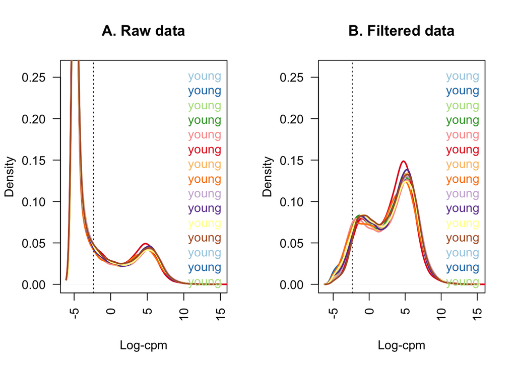

```r
par(mfrow=c(1,2))
plot(density(lcpm[,1]), col=col[1], lwd=2, ylim=c(0,0.26), las=2, main="", xlab="")
title(main="A. Raw data", xlab="Log-cpm")
abline(v=lcpm.cutoff, lty=3)
for (i in 2:nsamples){
den <- density(lcpm[,i])
lines(den$x, den$y, col=col[i], lwd=2)
}
legend("topright", group, text.col=col, bty="n")
lcpm <- cpm(y, log=TRUE)
plot(density(lcpm[,1]), col=col[1], lwd=2, ylim=c(0,0.26), las=2, main="", xlab="")
title(main="B. Filtered data", xlab="Log-cpm")
abline(v=lcpm.cutoff, lty=3)
for (i in 2:nsamples){
den <- density(lcpm[,i])
lines(den$x, den$y, col=col[i], lwd=2)
}
legend("topright", group, text.col=col, bty="n")
```

## Normalising gene expression distributions

Store the resultant values as a norm.factor dataset

```r
y <- calcNormFactors(y, method = "TMM")
y$samples$norm.factors
```

```
##  [1] 1.0571368 0.9917955 0.9983139 0.9869037 1.0029349 0.9730169 1.0106670
##  [8] 0.8851503 1.1065543 1.0690824 1.0174647 1.1487216 0.9198352 1.0468079
## [15] 0.8649093 1.0363952 0.9979118 0.9599107 0.8223611 1.0610713 0.8113690
## [22] 0.9333298 0.9615668 1.2614393 1.3004276 1.0280499 0.4522556 1.0905098
## [29] 0.9804883 1.1353039 0.9932927 1.1611616 1.0556749 1.1264282 1.1151424
## [36] 0.9992067 1.0336995 1.0073183 0.9930289 1.0434828
```

To have a better understanding of data normalization, the counts of the young_1 were reduced to 1% and the counts of the young_2 were increased to 1000%

```r
y2 <- y
y2$samples$norm.factors <- 1
y2$counts[,1] <- ceiling(y2$counts[,1]*0.01)
y2$counts[,2] <- y2$counts[,2]*10
```

This is the graph using unnormalised data

```
##  [1]  0.01571385 10.35119420  1.05777511  1.07973915  1.05684473  1.02734242
##  [7]  1.06260871  0.92496907  1.15640145  1.12192075  1.02876015  1.16010826
## [13]  0.96209594  1.11633882  0.91582790  1.08471463  1.05498613  1.03360064
## [19]  0.87401087  1.08837121  0.85541065  0.98380294  1.00068368  1.30706607
## [25]  1.37788317  1.08899218  0.47100725  1.13716264  1.02168393  1.20144892
## [31]  1.02960754  1.23312885  1.10457023  1.18725052  1.15131628  1.05549041
## [37]  1.08718363  1.07853525  1.02967524  1.10963034
```

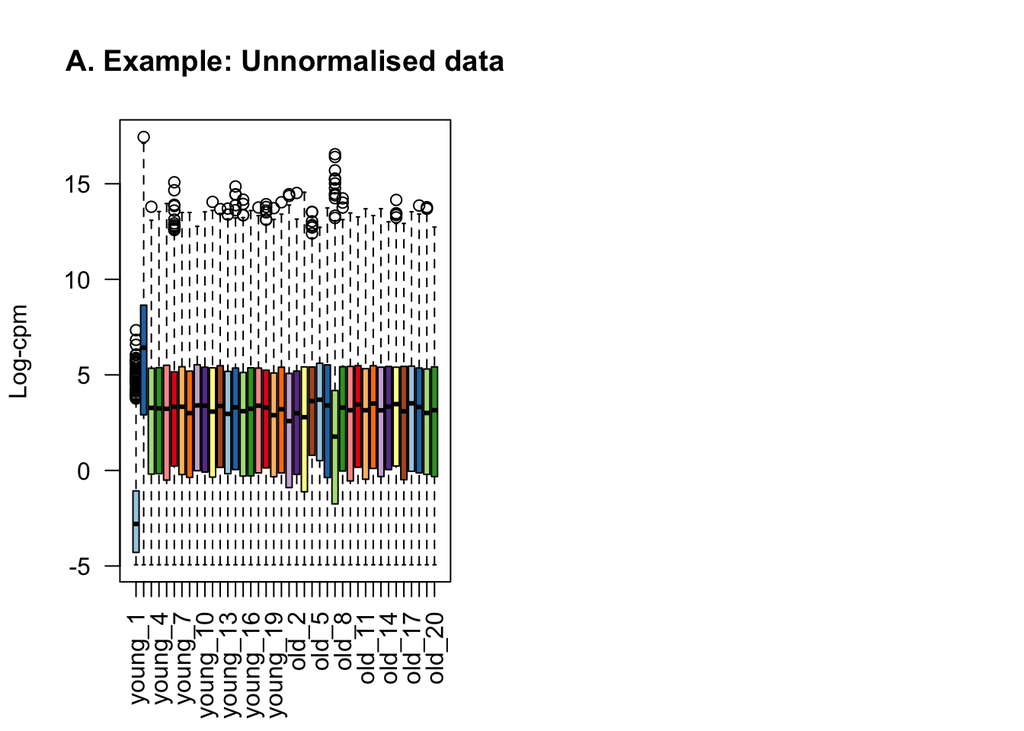

```r
par(mfrow=c(1,2))
lcpm <- cpm(y2, log=TRUE)
boxplot(lcpm, las=2, col=col, main="")
title(main="A. Example: Unnormalised data",ylab="Log-cpm")
y2 <- calcNormFactors(y2)
y2$samples$norm.factors
```

This is the graph using normalised data

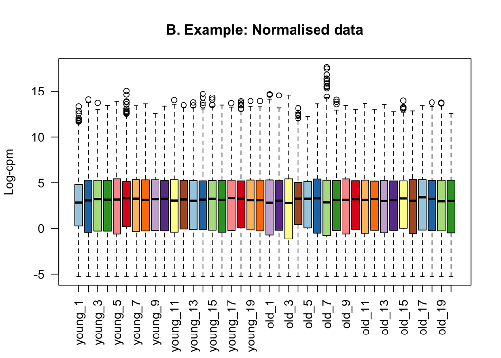

```r
lcpm <- cpm(y2, log=TRUE)
boxplot(lcpm, las=2, col=col, main="")
title(main="B. Example: Normalised data",ylab="Log-cpm")
```

## Unsupervised clustering of data

Generate graphs by using plotMDS in limma, and the graphs will show the similarity and dissimilarity in samples.

```r
lcpm <- cpm(y, log=TRUE)
par(mfrow=c(1,1))
col.group <- group
col.group
```

```
##  [1] "young" "young" "young" "young" "young" "young" "young" "young" "young"
## [10] "young" "young" "young" "young" "young" "young" "young" "young" "young"
## [19] "young" "young" "old"   "old"   "old"   "old"   "old"   "old"   "old"
## [28] "old"   "old"   "old"   "old"   "old"   "old"   "old"   "old"   "old"
## [37] "old"   "old"   "old"   "old"
```

```r
levels(col.group) <-  brewer.pal(nlevels(col.group), "Set1")
```

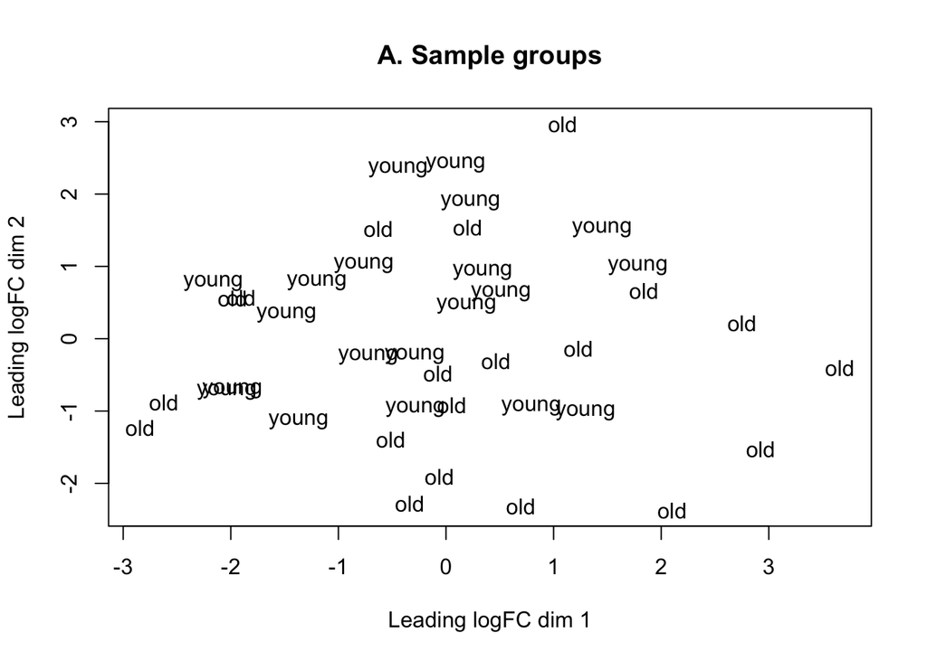

```r
col.group <- as.character(col.group)
col.group <- c("purple","red")[group]
plotMDS(lcpm, labels=group, col=col.group)
title(main="A. Sample groups")
```

An interactive version of this graph can be launched using glimma.

```r
library(Glimma)
glMDSPlot(lcpm,groups = group)
```

# Differential expression analysis

## Normalising gene expression distributions

create a design matrix with both the groups of data.

```r
design <- model.matrix(~0+group)
colnames(design) <- gsub("group", "", colnames(design))
design
```

```
##    old young
## 1    0     1
## 2    0     1
## 3    0     1
## 4    0     1
## 5    0     1
## 6    0     1
## 7    0     1
## 8    0     1
## 9    0     1
## 10   0     1
## 11   0     1
## 12   0     1
## 13   0     1
## 14   0     1
```

[output cut: 31 more lines]

Contrasts for the two groups are created and stored in a matrix

```r
contr.matrix <- makeContrasts(
   youngvsold = young-old,
   levels = colnames(design))
contr.matrix
```

```
##        Contrasts
## Levels  youngvsold
##   old           -1
##   young          1
```

## Removing heteroscedascity from count data

Transform the raw data into the normalised data

```
## An object of class "EList"
## $targets
##         group lib.size norm.factors
## young_1 young 57187947    1.0571368
## young_2 young 55655000    0.9917955
## young_3 young 59222764    0.9983139
## young_4 young 70160572    0.9869037
## young_5 young 61250873    1.0029349
## 35 more rows ...
##
## $E
##    young_1  young_2  young_3  young_4   young_5  young_6  young_7   young_8
## 1 6.100654 3.686383 4.762523 5.411651 4.8244771 5.719018 3.241206 7.3948584
## 3 5.450362 4.599770 5.768121 5.439875 4.6107180 4.700762 4.621405 5.6829263
## 4 4.432072 4.063423 3.543418 4.650819 4.1029460 3.831404 3.960510 3.8910933
```

[output cut: 75 more lines]

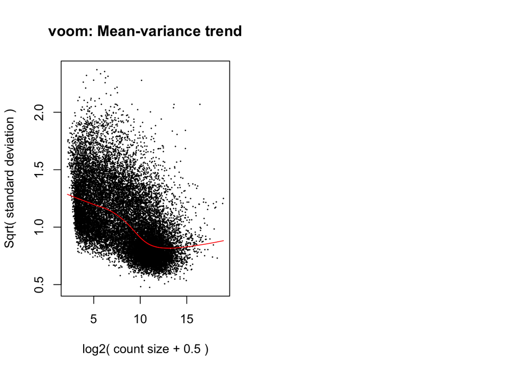

```r
par(mfrow=c(1,2))
v <- voom(y, design, plot=TRUE)
v
```

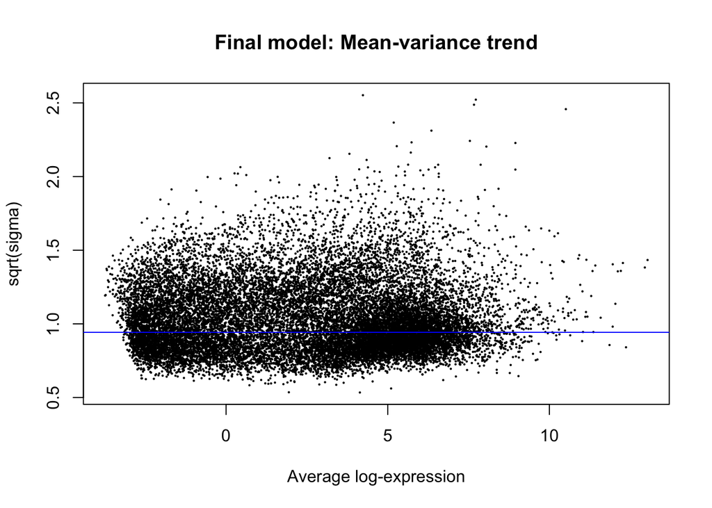

```r
vfit <- lmFit(v, design)
vfit <- contrasts.fit(vfit, contrasts=contr.matrix)
efit <- eBayes(vfit)
plotSA(efit, main="Final model: Mean-variance trend")
```

## Examining the number of DE genes

Use T-statistics to get significant differential gene expression

```r
summary(decideTests(efit))
```

```
##        youngvsold
## Down            0
## NotSig      19945
## Up              0
```

```r
tfit <- treat(vfit, lfc=0.01)
dt <- decideTests(tfit)
summary(dt)
```

```
##        youngvsold
## Down            0
## NotSig      19945
## Up              0
```

Unfortunately, after the change of lfc, I still cannot get any significant DGE. Therefore, the results showing below are nothing.

```r
de.common <- which(dt[,1]!=0)
length(de.common)
```

```
## [1] 0
```

```r
head(tfit$genes$SYMBOL[de.common], n=20)
```

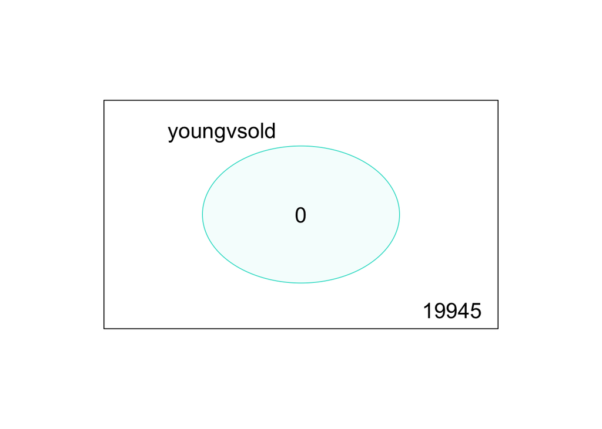

```r
vennDiagram(dt[,1], circle.col=c("turquoise", "salmon"))
```